# Trabalho de Regressão Linear

# Objetivo

Neste trabalho, irei utilizar a base de dados WineQualityWhite, que é uma base de dados que trata de vinhos com vários atributos, e os pesquisadores definiram uma variável resposta: qualidade. Ela varia de 0 a 10, em que 0 é péssimo e 10 é excelente.  
No entanto, como podemos tratar a qualidade como fator, não me preocuparei em fazer relação dessa variável em específico, pois teria que ter um tratado mais carinhoso com Regressão Logística, que não foi vista no curso.

## Descrição das variáveis

**Acidez Fixa:** Medida em gramas/litro, é responsável principalmente pela sensação de frescor na bebida  
**Acidez Volatil:** É relacionada com a formação de ácido acético e compostos relacionados no vinho, por conta de ação de bactérias durante o processo de vinificação  
**Acido Cítrico:** É usado para aumentar acidez, complementar um sabor.  
**Açúcar residual:** É o açúcar natural da uva.  
**Cloreto:** Participa ativamente da cor, sabor e aroma.  
**Dióxido de enxofre livre:** Age como um antioxicidante e antimicróbios para deixar o vinho mais durável.  
**Dióxido de enxofre total:** É a porção livre mais as que são devido a outras substâncias no vinho como aldeídos  
**Densidade:** Relação entre a massa do vinho e seu volume ocupado  
**pH:** Determina os níveis de ácidez do vinho  
**Sulfato:** Atuam como conservantes e intensificadores  
**Álcool:** Resultado da fermentação dos açúcares da uva.  
**Qualidade:** Nível de qualidade do vinho, em que 0 é péssimo e 10 é excelente

```r
library(dplyr)
library(data.table)
library(rmarkdown)

df <- 'WineQualityWhite.csv' %>%
  read.csv(sep = ',', header = TRUE) %>%
  data.table::setnames(new = c('AcidezFixa', 'AcidezVolatil', 'AcidoCitrico',
                               'AcucarResidual', 'Cloreto', 'DioxidoEnxofreLivre',
                               'DioxidoEnxofreTotal', 'Densidade', 'pH', 'Sulfato',
                               'Alcool', 'Qualidade'),
                       old = c('fixedacidity', 'volatileacidity',
                               'citricacid', 'residualsugar',
                               'chlorides', 'freesulfurdioxide',
                               'totalsulfurdioxide', 'density', 'pH',
                               'sulphates', 'alcohol', 'quality'))

rmarkdown::paged_table(df)
```

| AcidezFixa | AcidezVolatil | AcidoCitrico | AcucarResidual | Cloreto | DioxidoEnxofreLivre | DioxidoEnxofreTotal | Densidade | pH | Sulfato | Alcool | Qualidade |
| --- | --- | --- | --- | --- | --- | --- | --- | --- | --- | --- | --- |
| 7.00 | 0.27 | 0.36 | 20.70 | 45.00 | 45.0 | 170.0 | 1001.000000 | 3.00 | 0.45 | 8.800000 | 6 |
| 6.30 | 0.30 | 0.34 | 1.60 | 49.00 | 14.0 | 132.0 | 994.000000 | 3.30 | 0.49 | 9.500000 | 6 |
| 8.10 | 0.28 | 0.40 | 6.90 | 0.05 | 30.0 | 97.0 | 0.995100 | 3.26 | 0.44 | 10.100000 | 6 |
| 7.20 | 0.23 | 0.32 | 8.50 | 58.00 | 47.0 | 186.0 | 0.995600 | 3.19 | 0.40 | 9.900000 | 6 |
| 7.20 | 0.23 | 0.32 | 8.50 | 58.00 | 47.0 | 186.0 | 0.995600 | 3.19 | 0.40 | 9.900000 | 6 |
| 8.10 | 0.28 | 0.40 | 6.90 | 0.05 | 30.0 | 97.0 | 0.995100 | 3.26 | 0.44 | 10.100000 | 6 |
| 6.20 | 0.32 | 0.16 | 7.00 | 45.00 | 30.0 | 136.0 | 0.994900 | 3.18 | 0.47 | 9.600000 | 6 |
| 7.00 | 0.27 | 0.36 | 20.70 | 45.00 | 45.0 | 170.0 | 1001.000000 | 3.00 | 0.45 | 8.800000 | 6 |
| 6.30 | 0.30 | 0.34 | 1.60 | 49.00 | 14.0 | 132.0 | 994.000000 | 3.30 | 0.49 | 9.500000 | 6 |
| 8.10 | 0.22 | 0.43 | 1.50 | 44.00 | 28.0 | 129.0 | 0.993800 | 3.22 | 0.45 | 11.000000 | 6 |

[output cut: 4888 more lines]

Neste trabalho, me preocuparei com o nível de pH, em relação a outras variáveis.

# Análise Exploratória dos Dados

Nesta etapa, será de objetivo primário verificar outliers nas variáveis. Isso porque, quanto mais outliers o modelo tiver, mais ele será pertubado. Por isso, é importante selecionar as variáveis que tenham o menor número de variáveis possíveis. Caso isso não for possível (isso é, todas as variáveis tiver um número alto de outliers), será feito a regressão mesmo assim, mas sem muita certeza se os resultados estão certos.

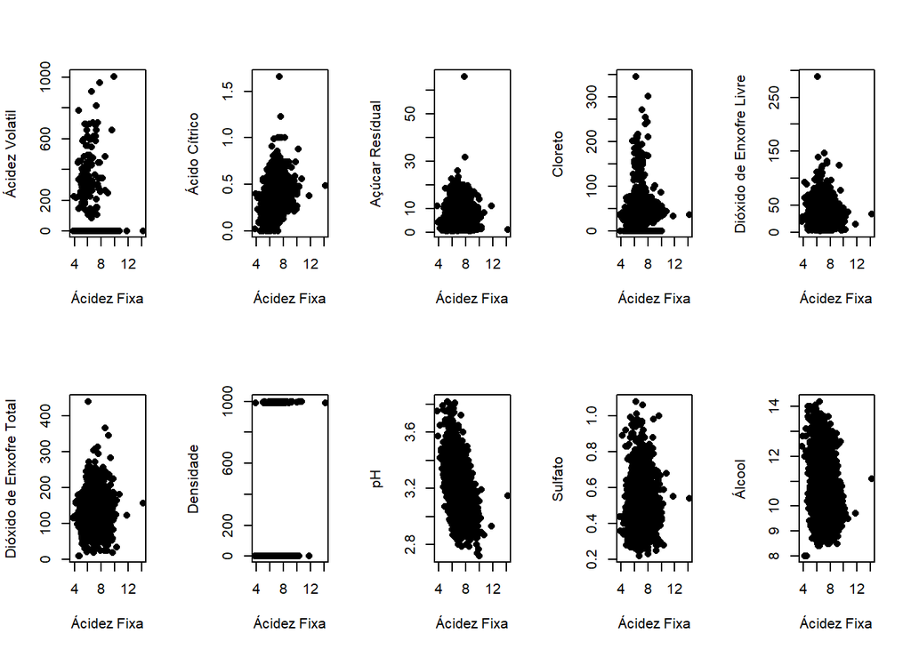

```r
###### ÁCIDEZ FIXA


par(mfrow = c(2, 5))
plot(x = df$AcidezFixa,
     y = df$AcidezVolatil,
     xlab = 'Ácidez Fixa',
     ylab = 'Ácidez Volatil',
     pch = 16)


plot(x = df$AcidezFixa,
     y = df$AcidoCitrico,
     xlab = 'Ácidez Fixa',
     ylab = 'Ácido Cítrico',
     pch = 16)

plot(x = df$AcidezFixa,
     y = df$AcucarResidual,
     xlab = 'Ácidez Fixa',
     ylab = 'Açúcar Resídual',
     pch = 16)


plot(x = df$AcidezFixa,
     y = df$Cloreto,
     xlab = 'Ácidez Fixa',
     ylab = 'Cloreto',
     pch = 16)

plot(x = df$AcidezFixa,
     y = df$DioxidoEnxofreLivre,
     xlab = 'Ácidez Fixa',
     ylab = 'Dióxido de Enxofre Livre',
     pch = 16)

plot(x = df$AcidezFixa,
     y = df$DioxidoEnxofreTotal,
     xlab = 'Ácidez Fixa',
     ylab = 'Dióxido de Enxofre Total',
     pch = 16)

plot(x = df$AcidezFixa,
     y = df$Densidade,
     xlab = 'Ácidez Fixa',
     ylab = 'Densidade',
     pch = 16)

plot(x = df$AcidezFixa,
     y = df$pH,
     xlab = 'Ácidez Fixa',
     ylab = 'pH',
     pch = 16)

plot(x = df$AcidezFixa,
     y = df$Sulfato,
     xlab = 'Ácidez Fixa',
     ylab = 'Sulfato',
     pch = 16)

plot(x = df$AcidezFixa,
     y = df$Alcool,
     xlab = 'Ácidez Fixa',
     ylab = 'Álcool',
     pch = 16)
```

```r
###### ÁCIDEZ VOLATIL

# par(mfrow = c(4, 2))
#
# plot(x = df$AcidezVolatil,
#      y = df$AcidoCitrico,
#      xlab = 'Ácidez Volatil',
#      ylab = 'Ácido Cítrico',
#      pch = 16)
#
# plot(x = df$AcidezVolatil,
#      y = df$AcucarResidual,
#      xlab = 'Ácidez Volatil',
#      ylab = 'Açúcar Residual',
#      pch = 16)
#
# plot(x = df$AcidezVolatil,
#      y = df$Cloreto,
#      xlab = 'Ácidez Volatil',
#      ylab = 'Cloreto',
#      pch = 16)
#
# plot(x = df$AcidezVolatil,
#      y = df$DioxidoEnxofreLivre,
#      xlab = 'Ácidez Volatil',
#      ylab = 'Dióxido de Enxofre Livre',
#      pch = 16)
#
# plot(x = df$AcidezVolatil,
#      y = df$DioxidoEnxofreTotal,
#      xlab = 'Ácidez Volatil',
#      ylab = 'Dióxido de Enxofre Total',
#      pch = 16)
#
# plot(x = df$AcidezVolatil,
#      y = df$Densidade,
#      xlab = 'Ácidez Volatil',
#      ylab = 'Densidade',
#      pch = 16)
#
# plot(x = df$AcidezVolatil,
#      y = df$pH,
#      xlab = 'Ácidez Volatil',
#      ylab = 'pH',
#      pch = 16)
#
# plot(x = df$AcidezVolatil,
#      y = df$Sulfato,
#      xlab = 'Ácidez Volatil',
#      ylab = 'Sulfato',
#      pch = 16)
#
# plot(x = df$AcidezVolatil,
#      y = df$Alcool,
#      xlab = 'Ácidez Volatil',
#      ylab = 'Álcool',
#      pch = 16)
```

## Boxplot

Irei me preocupar, nessa parte, com o gráfico de boxplot das variáveis em questão. Isso porque, por meio disso, se é possível verificar possíveis valores discrepantes que podem atrapalhar no modelo de regressão.

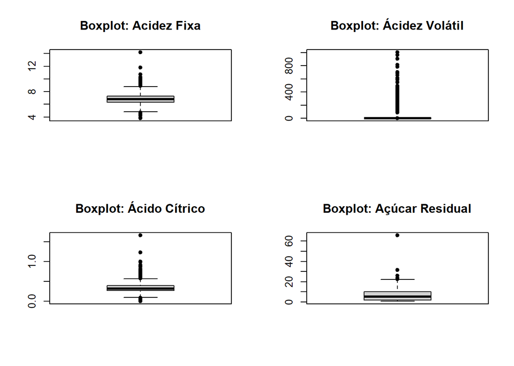

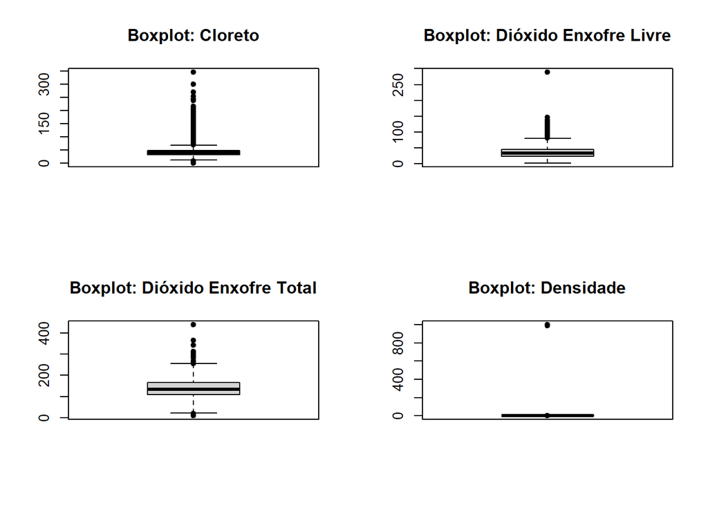

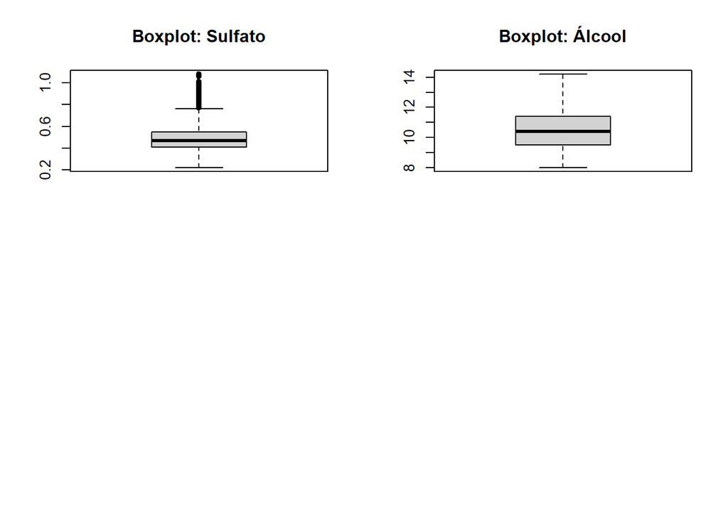

# Construção do modelo linear

```r
df2 <- df[, -12]
library(MASS)
fit1 <- lm(formula = pH ~ . ,data = df2)
summary(fit1)
```

```
##
## Call:
## lm(formula = pH ~ ., data = df2)
##
## Residuals:
##      Min       1Q   Median       3Q      Max
## -0.38803 -0.08540 -0.00843  0.07403  0.57476
##
## Coefficients:
##                       Estimate Std. Error t value Pr(>|t|)
## (Intercept)          3.565e+00  3.060e-02 116.511  < 2e-16 ***
## AcidezFixa          -7.295e-02  2.382e-03 -30.626  < 2e-16 ***
## AcidezVolatil        5.128e-05  2.731e-05   1.878  0.06047 .
## AcidoCitrico        -5.119e-02  1.647e-02  -3.108  0.00189 **
## AcucarResidual      -5.301e-03  4.335e-04 -12.228  < 2e-16 ***
## Cloreto             -3.486e-04  7.902e-05  -4.412 1.05e-05 ***
## DioxidoEnxofreLivre -4.502e-04  1.426e-04  -3.157  0.00160 **
## DioxidoEnxofreTotal  5.474e-04  6.259e-05   8.746  < 2e-16 ***
## Densidade            1.636e-05  7.823e-06   2.091  0.03661 *
## Sulfato              1.733e-01  1.671e-02  10.367  < 2e-16 ***
## Alcool               3.979e-03  1.879e-03   2.118  0.03425 *
## ---
## Signif. codes:  0 '***' 0.001 '**' 0.01 '*' 0.05 '.' 0.1 ' ' 1
##
## Residual standard error: 0.1314 on 4887 degrees of freedom
## Multiple R-squared:  0.2448, Adjusted R-squared:  0.2433
## F-statistic: 158.4 on 10 and 4887 DF,  p-value: < 2.2e-16
```

```r
stepAIC(fit1)
```

```
## Start:  AIC=-19873.53
## pH ~ AcidezFixa + AcidezVolatil + AcidoCitrico + AcucarResidual +
##     Cloreto + DioxidoEnxofreLivre + DioxidoEnxofreTotal + Densidade +
##     Sulfato + Alcool
##
##                       Df Sum of Sq     RSS    AIC
## <none>                              84.319 -19874
## - AcidezVolatil        1    0.0608  84.380 -19872
## - Densidade            1    0.0754  84.395 -19871
## - Alcool               1    0.0774  84.397 -19871
## - AcidoCitrico         1    0.1667  84.486 -19866
## - DioxidoEnxofreLivre  1    0.1720  84.491 -19866
## - Cloreto              1    0.3358  84.655 -19856
## - DioxidoEnxofreTotal  1    1.3197  85.639 -19800
## - Sulfato              1    1.8545  86.174 -19769
## - AcucarResidual       1    2.5797  86.899 -19728
## - AcidezFixa           1   16.1833 100.503 -19016
```

```
##
## Call:
## lm(formula = pH ~ AcidezFixa + AcidezVolatil + AcidoCitrico +
##     AcucarResidual + Cloreto + DioxidoEnxofreLivre + DioxidoEnxofreTotal +
##     Densidade + Sulfato + Alcool, data = df2)
##
## Coefficients:
##         (Intercept)           AcidezFixa        AcidezVolatil
##           3.565e+00           -7.295e-02            5.128e-05
##        AcidoCitrico       AcucarResidual              Cloreto
##          -5.119e-02           -5.301e-03           -3.486e-04
## DioxidoEnxofreLivre  DioxidoEnxofreTotal            Densidade
##          -4.502e-04            5.474e-04            1.636e-05
##             Sulfato               Alcool
##           1.733e-01            3.979e-03
```

```r
modelo <- lm(pH ~ AcidoCitrico + AcidezFixa + AcucarResidual + Cloreto + DioxidoEnxofreTotal + Densidade + Sulfato + Alcool + DioxidoEnxofreLivre, data = df2)
summary(modelo)
```

```
##
## Call:
## lm(formula = pH ~ AcidoCitrico + AcidezFixa + AcucarResidual +
##     Cloreto + DioxidoEnxofreTotal + Densidade + Sulfato + Alcool +
##     DioxidoEnxofreLivre, data = df2)
##
## Residuals:
##      Min       1Q   Median       3Q      Max
## -0.38821 -0.08560 -0.00871  0.07427  0.57395
##
## Coefficients:
##                       Estimate Std. Error t value Pr(>|t|)
## (Intercept)          3.570e+00  3.050e-02 117.074  < 2e-16 ***
## AcidoCitrico        -5.341e-02  1.643e-02  -3.250  0.00116 **
## AcidezFixa          -7.331e-02  2.375e-03 -30.872  < 2e-16 ***
## AcucarResidual      -5.291e-03  4.336e-04 -12.202  < 2e-16 ***
## Cloreto             -3.454e-04  7.902e-05  -4.371 1.26e-05 ***
## DioxidoEnxofreTotal  5.482e-04  6.260e-05   8.757  < 2e-16 ***
## Densidade            1.668e-05  7.823e-06   2.133  0.03301 *
## Sulfato              1.734e-01  1.672e-02  10.374  < 2e-16 ***
## Alcool               3.883e-03  1.879e-03   2.067  0.03882 *
## DioxidoEnxofreLivre -4.649e-04  1.424e-04  -3.265  0.00110 **
## ---
## Signif. codes:  0 '***' 0.001 '**' 0.01 '*' 0.05 '.' 0.1 ' ' 1
##
## Residual standard error: 0.1314 on 4888 degrees of freedom
## Multiple R-squared:  0.2443, Adjusted R-squared:  0.2429
## F-statistic: 175.6 on 9 and 4888 DF,  p-value: < 2.2e-16
```